# Impacts of Severe Weather events in the US

# Synopsis

U.S. National Oceanic and Atmospheric Administration’s (NOAA) storm database was analysed to determine its health and economics impacts. The data bettween 1950 and 2011 was used to anwser the following 2 questions.

1. What weather event causes the most impact to health.
2. what weather event type causes the most impact to economics.

We find that tornados causes the most impact both in injuries and fatalities. Economically, floods are responsible for the most about of damage.

# Setup

ggplot is loaded for graphing The data is read from its zip form and simplied by removing unnessary variables for the analysis.

```r
library(ggplot2)
setwd("C:/Workspace/rep2")
data=read.csv(bzfile("repdata-data-stormData.csv.bz2"), sep=",", header=T)
data.reduced <- data.frame(EVTYPE=data$EVTYPE, FATALITIES=data$FATALITIES, INJURIES=data$INJURIES, PROPDMG=data$PROPDMG, PROPDMGEXP=data$PROPDMGEXP, CROPDMG=data$CROPDMG, CROPDMGEXP=data$CROPDMGEXP)
```

# Health Impact

## Fatalities

Fatalities are aggregated across events and ploted on a bar plot

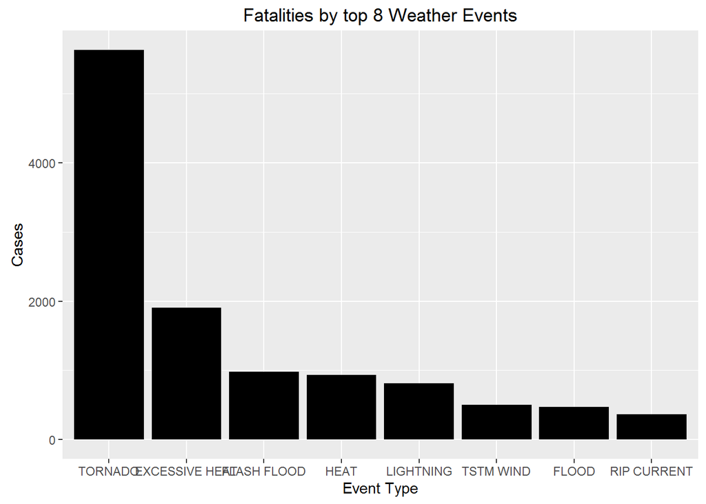

```r
fatalities <- aggregate(FATALITIES ~ EVTYPE, data=data, sum)
fatalities <- fatalities[order(-fatalities$FATALITIES), ][1:8, ]
fatalities$EVTYPE <- factor(fatalities$EVTYPE, levels = fatalities$EVTYPE)

ggplot(fatalities, aes(x = EVTYPE, y = FATALITIES))+
    geom_bar(stat = "identity", fill = "black") +
    ggtitle("Fatalities by top 8 Weather Events")+
    xlab("Event Type") + ylab("Cases")
```

Tornados caused the most amount of fatalities

## Injuries

Injuries are aggregated across events and ploted on a bar plot

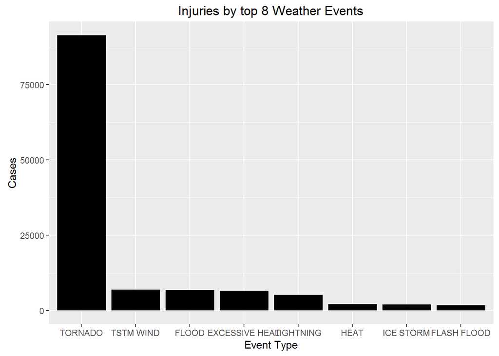

```r
injuries <- aggregate(INJURIES ~ EVTYPE, data=data.reduced, sum)
injuries <- injuries[order(-injuries$INJURIES), ][1:8, ]
injuries$EVTYPE <- factor(injuries$EVTYPE, levels = injuries$EVTYPE)

ggplot(injuries, aes(x = EVTYPE, y = INJURIES))+

    geom_bar(stat = "identity", fill = "black")+
    ggtitle("Injuries by top 8 Weather Events")+
    xlab("Event Type") + ylab("Cases")
```

Tornado caused the most amount of injuries

# Economic Impact

First the multipliers are applied to standardise the numeric units of the data

```r
#Now we numerate the muliplers to get numeric values for the damages.
data.reduced$PROPDMGV = 0
data.reduced[data.reduced$PROPDMGEXP == "H", ]$PROPDMGV = data.reduced[data.reduced$PROPDMGEXP == "H", ]$PROPDMG * 10^2
data.reduced[data.reduced$PROPDMGEXP == "K", ]$PROPDMGV = data.reduced[data.reduced$PROPDMGEXP == "K", ]$PROPDMG * 10^3
data.reduced[data.reduced$PROPDMGEXP == "M", ]$PROPDMGV = data.reduced[data.reduced$PROPDMGEXP == "M", ]$PROPDMG * 10^6
data.reduced[data.reduced$PROPDMGEXP == "B", ]$PROPDMGV = data.reduced[data.reduced$PROPDMGEXP == "B", ]$PROPDMG * 10^9

data.reduced$CROPDMGV = 0
data.reduced[data.reduced$CROPDMGEXP == "H", ]$CROPDMGV = data.reduced[data.reduced$CROPDMGEXP == "H", ]$CROPDMG * 10^2
data.reduced[data.reduced$CROPDMGEXP == "K", ]$CROPDMGV = data.reduced[data.reduced$CROPDMGEXP == "K", ]$CROPDMG * 10^3
data.reduced[data.reduced$CROPDMGEXP == "M", ]$CROPDMGV = data.reduced[data.reduced$CROPDMGEXP == "M", ]$CROPDMG * 10^6
data.reduced[data.reduced$CROPDMGEXP == "B", ]$CROPDMGV = data.reduced[data.reduced$CROPDMGEXP == "B", ]$CROPDMG * 10^9
```

The values of property and crop damages are combined and aggregated across events.

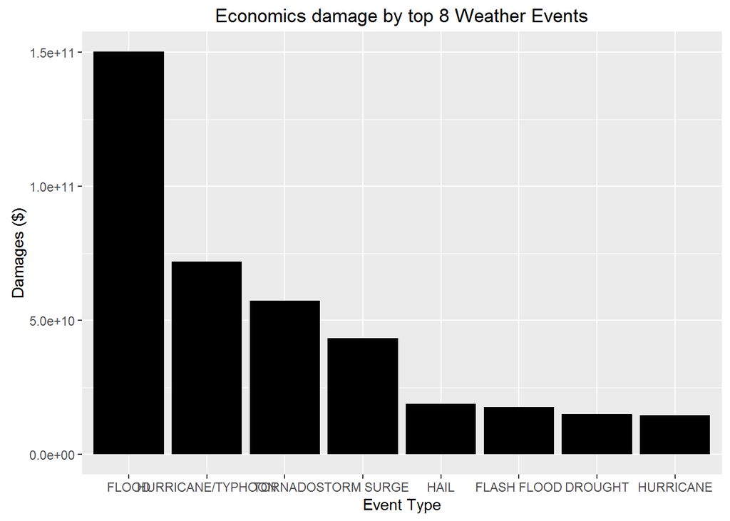

```r
damages <- aggregate(PROPDMGV + CROPDMGV ~ EVTYPE, data=data.reduced, sum)
names(damages) = c("EVTYPE", "TOTALDAMAGE")
damages <- damages[order(-damages$TOTALDAMAGE), ][1:8, ]
damages$EVTYPE <- factor(damages$EVTYPE, levels = damages$EVTYPE)

ggplot(damages, aes(x = EVTYPE, y = TOTALDAMAGE))+
    geom_bar(stat = "identity", fill = "black")+
    ggtitle("Economics damage by top 8 Weather Events")+
    xlab("Event Type") + ylab("Damages ($)")
```

Flood Caused the most amount of economic damage